# House price prediction using lasso and ridge regression

EXP 1 - Build a machine learning model for house price prediction analysis using lasso and ridge regression

EXP 3 - Compare the differences between the accuracies obtained using ridge and lasso regression in first experiment

EXP 4 - For the above build regression model, perform model evaluation, feature selection and parameter tuning

```python
import os
import pandas as pd
import numpy as np
import matplotlib.pyplot as plt
import seaborn as sns
from sklearn.model_selection import train_test_split, cross_val_score
from sklearn.dummy import DummyRegressor
from sklearn.linear_model import LinearRegression, Lasso, Ridge
from sklearn.metrics import mean_squared_error
from sklearn.preprocessing import StandardScaler
```

#### Training Data

```python
housing = pd.read_csv(r'C:\Users\yadav\OneDrive\Desktop\Prepration\DL_Datasets\Data Files\train.csv')
pd.set_option('display.max_columns', None)
```

#### Test Data

```python
test = pd.read_csv('C:\Users\yadav\OneDrive\Desktop\Prepration\DL_Datasets\Data Files\test.csv')
pd.set_option('display.max_columns', None)
```

```python
housing.shape
```

```
(2051, 81)
```

```python
test.shape
```

```
(878, 80)
```

```python
np.sqrt(housing.shape[0])
```

```
45.28796749689701
```

```python
housing.isnull()
```

[output not shown]

```python
 test.isnull()
```

[output not shown]

```python
housing.describe()
```

|  | Lot Frontage | Lot Area | Overall Qual | Overall Cond | Year Built | Year Remod/Add | Mas Vnr Area | BsmtFin SF 1 | BsmtFin SF 2 | Bsmt Unf SF | Total Bsmt SF | 1st Flr SF | 2nd Flr SF | Low Qual Fin SF | Gr Liv Area | Bsmt Full Bath | Bsmt Half Bath | Full Bath | Half Bath | Bedroom AbvGr | Kitchen AbvGr | TotRms AbvGrd | Fireplaces | Garage Cars | Garage Area | Wood Deck SF | Open Porch SF | Enclosed Porch | 3Ssn Porch | … |
| --- | --- | --- | --- | --- | --- | --- | --- | --- | --- | --- | --- | --- | --- | --- | --- | --- | --- | --- | --- | --- | --- | --- | --- | --- | --- | --- | --- | --- | --- | --- |
| count | 2051.000000 | 2051.000000 | 2051.000000 | 2051.000000 | 2051.000000 | 2051.000000 | 2051.000000 | 2051.000000 | 2051.000000 | 2051.000000 | 2051.000000 | 2051.000000 | 2051.000000 | 2051.000000 | 2051.000000 | 2051.000000 | 2051.000000 | 2051.000000 | 2051.000000 | 2051.000000 | 2051.000000 | 2051.000000 | 2051.000000 | 2051.000000 | 2051.000000 | 2051.000000 | 2051.000000 | 2051.000000 | 2051.000000 | … |
| mean | 69.055200 | 10065.208191 | 6.112140 | 5.562165 | 1971.708922 | 1984.190151 | 98.626524 | 442.084837 | 47.935641 | 567.451487 | 1057.471965 | 1164.488055 | 329.329108 | 5.512921 | 1499.330083 | 0.427109 | 0.063384 | 1.577279 | 0.371039 | 2.843491 | 1.042906 | 6.435885 | 0.590931 | 1.775719 | 473.440761 | 93.833740 | 47.556802 | 22.571916 | 2.591419 | … |
| std | 21.306357 | 6742.488909 | 1.426271 | 1.104497 | 30.177889 | 21.036250 | 174.324690 | 461.195041 | 164.964052 | 445.022846 | 449.908003 | 396.446923 | 425.671046 | 51.068870 | 500.447829 | 0.522589 | 0.251590 | 0.549279 | 0.501043 | 0.826618 | 0.209790 | 1.560225 | 0.638516 | 0.765357 | 216.135102 | 128.549416 | 66.747241 | 59.845110 | 25.229615 | … |
| min | 21.000000 | 1300.000000 | 1.000000 | 1.000000 | 1872.000000 | 1950.000000 | 0.000000 | 0.000000 | 0.000000 | 0.000000 | 0.000000 | 334.000000 | 0.000000 | 0.000000 | 334.000000 | 0.000000 | 0.000000 | 0.000000 | 0.000000 | 0.000000 | 0.000000 | 2.000000 | 0.000000 | 0.000000 | 0.000000 | 0.000000 | 0.000000 | 0.000000 | 0.000000 | … |
| 25% | 60.000000 | 7500.000000 | 5.000000 | 5.000000 | 1953.500000 | 1964.500000 | 0.000000 | 0.000000 | 0.000000 | 220.000000 | 793.000000 | 879.500000 | 0.000000 | 0.000000 | 1129.000000 | 0.000000 | 0.000000 | 1.000000 | 0.000000 | 2.000000 | 1.000000 | 5.000000 | 0.000000 | 1.000000 | 319.000000 | 0.000000 | 0.000000 | 0.000000 | 0.000000 | … |
| 50% | 69.055200 | 9430.000000 | 6.000000 | 5.000000 | 1974.000000 | 1993.000000 | 0.000000 | 368.000000 | 0.000000 | 474.000000 | 994.000000 | 1093.000000 | 0.000000 | 0.000000 | 1444.000000 | 0.000000 | 0.000000 | 2.000000 | 0.000000 | 3.000000 | 1.000000 | 6.000000 | 1.000000 | 2.000000 | 480.000000 | 0.000000 | 27.000000 | 0.000000 | 0.000000 | … |
| 75% | 78.000000 | 11513.500000 | 7.000000 | 6.000000 | 2001.000000 | 2004.000000 | 159.000000 | 733.500000 | 0.000000 | 811.000000 | 1318.500000 | 1405.000000 | 692.500000 | 0.000000 | 1728.500000 | 1.000000 | 0.000000 | 2.000000 | 1.000000 | 3.000000 | 1.000000 | 7.000000 | 1.000000 | 2.000000 | 576.000000 | 168.000000 | 70.000000 | 0.000000 | 0.000000 | … |
| max | 313.000000 | 159000.000000 | 10.000000 | 9.000000 | 2010.000000 | 2010.000000 | 1600.000000 | 5644.000000 | 1474.000000 | 2336.000000 | 6110.000000 | 5095.000000 | 1862.000000 | 1064.000000 | 5642.000000 | 3.000000 | 2.000000 | 4.000000 | 2.000000 | 8.000000 | 3.000000 | 15.000000 | 4.000000 | 5.000000 | 1418.000000 | 1424.000000 | 547.000000 | 432.000000 | 508.000000 | … |

```python
housing[housing['SalePrice'] == housing['SalePrice'].min()] # Quality is poor, seems to be okay
```

|  | Id | PID | MS SubClass | MS Zoning | Lot Frontage | Lot Area | Street | Alley | Lot Shape | Land Contour | Utilities | Lot Config | Land Slope | Neighborhood | Condition 1 | Condition 2 | Bldg Type | House Style | Overall Qual | Overall Cond | Year Built | Year Remod/Add | Roof Style | Roof Matl | Exterior 1st | Exterior 2nd | Mas Vnr Type | Mas Vnr Area | Exter Qual | … |
| --- | --- | --- | --- | --- | --- | --- | --- | --- | --- | --- | --- | --- | --- | --- | --- | --- | --- | --- | --- | --- | --- | --- | --- | --- | --- | --- | --- | --- | --- | --- |
| 1628 | 182 | 902207130 | 30 | RM | 68.0 | 9656 | Pave | NA | Reg | Lvl | AllPub | Inside | Gtl | OldTown | Norm | Norm | 1Fam | 1Story | 2 | 2 | 1923 | 1970 | Gable | CompShg | AsbShng | AsbShng | None | 0.0 | TA | … |

#### Categorical Values

```python
categorical_vars = housing.select_dtypes(exclude = ['number'])
```

```python
categorical_vars.columns
```

```
Index(['Id', 'PID', 'MS SubClass', 'MS Zoning', 'Street', 'Alley', 'Lot Shape',
       'Land Contour', 'Utilities', 'Lot Config', 'Land Slope', 'Neighborhood',
       'Condition 1', 'Condition 2', 'Bldg Type', 'House Style', 'Roof Style',
       'Roof Matl', 'Exterior 1st', 'Exterior 2nd', 'Mas Vnr Type',
       'Exter Qual', 'Exter Cond', 'Foundation', 'Bsmt Qual', 'Bsmt Cond',
       'Bsmt Exposure', 'BsmtFin Type 1', 'BsmtFin Type 2', 'Heating',
       'Heating QC', 'Central Air', 'Electrical', 'Kitchen Qual', 'Functional',
       'Fireplace Qu', 'Garage Type', 'Garage Yr Blt', 'Garage Finish',
       'Garage Qual', 'Garage Cond', 'Paved Drive', 'Pool QC', 'Fence',
       'Misc Feature', 'Mo Sold', 'Sale Type'],
      dtype='object')
```

### Graphing Functions

```python
def create_scatter(df, x_col, y_col, title, x_label, y_label, marker_size = 4, color='mediumseagreen', plot_size = (10,6), hue = None):
    plt.figure(figsize=plot_size)
    ax = sns.scatterplot(x = x_col, y = y_col, data = df, s=marker_size, color=color, hue = hue)
    plt.title(title, fontdict = {'fontsize': 14})
    plt.xlabel(x_label, fontdict = {'fontsize':13})
    plt.ylabel(y_label, fontdict = {'fontsize':13})
    plt.tight_layout;
    return ax
```

```python
def create_hist(feature, num_bins, title, x_label, y_label, color='mediumseagreen', edgecolor='black', plot_size = (10,6)):
    plt.figure(figsize=plot_size)
    feature.hist(bins = num_bins, color=color, edgecolor=edgecolor, grid = False)
    plt.title(title, fontdict = {'fontsize': 14})
    plt.xlabel(x_label, fontdict = {'fontsize':13})
    plt.ylabel(y_label, fontdict = {'fontsize':13})
    plt.tight_layout;
```

```python
def create_bar_xticks(df, x_col, y_col, title, x_label, y_label, hue=None, color = 'mediumseagreen', plot_size = (10,6), lw = 1.5, x_tick_labels = None, palette = None):
    plt.figure(figsize=plot_size)
    ax = sns.barplot(x = x_col, y = y_col, data = df, hue = hue, color = color, linewidth = lw, edgecolor = 'black', palette = palette)
    plt.title(title, fontdict = {'fontsize': 14})
    plt.xlabel(x_label, fontdict = {'fontsize':13})
    plt.ylabel(y_label, fontdict = {'fontsize':13})
    ax.set_xticklabels(x_tick_labels)
    plt.tight_layout;
```

```python
def create_bar(df, x_col, y_col, title, x_label, y_label, hue=None, color = 'mediumseagreen', plot_size = (10,6), lw = 1.5):
    plt.figure(figsize=plot_size)
    ax = sns.barplot(x = x_col, y = y_col, data = df, hue = hue, color = color, linewidth = lw, edgecolor = 'black')
    plt.title(title, fontdict = {'fontsize': 14})
    plt.xlabel(x_label, fontdict = {'fontsize':13})
    plt.ylabel(y_label, fontdict = {'fontsize':13})
    plt.tight_layout;
```

```python
def create_count(df, x_col, title, x_label, color = 'mediumseagreen', plot_size = (10,6)):
    plt.figure(figsize = plot_size)
    sns.countplot(x=x_col, data = df, palette = 'viridis')
    plt.title(title, fontdict= {'fontsize':14})
    plt.xlabel(f'Number of {x_label} per Property', fontdict= {'fontsize':12})
    plt.ylabel('Number of Properties', fontdict= {'fontsize':12})
```

```python
vis_df = housing.copy()
```

```python
# Rename columns to be more readable for heatmap
vis_df.rename(columns = {
    'MS SubClass':'Building Class',
    'MS Zoning': 'Zoning Class',
    'Street' : 'Street Type',
    'Lot Config':'Lot Configuration',
    'Condition1': 'Proximity to Main Road or Railroad 1',
    'Condition 2' : 'Proximity to Main Road or Railroad 2',
    'BldgType':'Building Type',
    'Overall Qual': 'Overall Quality',
    'Overall Cond': 'Overall Condition',
    'Year Remod/Add': 'Remodel Date',
    'Roof Matl': 'Roof Material',
    'Exterior 1st':'Exterior Covering 1',
    'Exterior 2nd': 'Exterior Covering 2',
    'Mas Vnr Type': 'Masonry Veneer Type',
    'Mas Vnr Area': 'Masonry Veneer Area',
    'Exter Qual': 'Exterior Material Quality',
    'Exter Cond': 'Exterior Condition Quality',
    'Bsmt Qual':'Basement Quality',
    'Bsmt Cond': 'Basement Condition',
    'Basmt Exposure': 'Basement Exposure',
    'BsmtFin Type 1': 'Quality of Finished Basement 1',
    'BsmtFin Type 2': 'Quality of Finished Basement 2',
    'BsmtFin SF 1': 'Square Feet of Finished Basement 1',
    'BsmtFin SF 2': 'Square Feet of Finished Basement 2',
    'Bsmt Unf SF': 'Square Feet of Unfinished Basement',
    'Total Bsmt SF': 'Total Basement Square Feet',
    'Heating': 'Heating Type',
    'Heating QC': 'Heating Quality and Condition',
    '1st Flr SF': '1st Floor Square Feet',
    '2nd Flr SF': '2nd Floor Square Feet',
    'Low Qual Fin SF':'Low Quality Finished Square Feet',
    'Gr Liv Area': 'Above-Grade Living Area',
    'Bsmt Full Bath': 'Basement Full Bathrooms',
    'Bsmt Half Bath': 'Basement Half Bathrooms',
    'Full Bath': 'Full Bathrooms',
    'Half Bath': 'Half Bathrooms',
    'Bedroom': 'Bedrooms',
    'Kitchen':'Kitchens',
    'Kitchen Qual': 'Kitchen Quality',
    'TotRms AbvGrd': 'Total Rooms Above Grade',
    'Functional':'Functionality',
    'Fireplace Qu': 'Fireplace Quality',
    'Garage Yr Blt': "Year Garage Built",
    'Garage Finish': 'Interior Finish of Garage',
    'Garage Cars': 'Size of Garage (Cars)',
    'Garage Area': 'Size of Garage (Square Feet)',
    'Garage Qual':'Garage Quality',
    'Garage Cond': 'Garage Condition',
    'Paved Drive': 'Extent of Driveway Pavement',
    'Wood Deck SF': 'Wood Deck Square Feet',
    'Open Porch SF': 'Open Porch Square Feet',
    'Enclosed Porch': 'Enclosed Porch Square Feet',
    '3Ssn Porch': '3 Season Porch Square Feet',
    'Screen Porch': 'Screen Porch Square Feet',
    'Pool Area': 'Pool Area (Square Feet)',
    'Pool QC': 'Pool Quality',
    'Fence':'Fence Quality',
    'Misc Feature':'Miscellaneous Feature',
    'Misc Val': 'Value of Miscellaneous Feature',
    'Mo Sold': 'Month Sold',
    'Yr Sold': 'Year Sold',
    'SalePrice': 'Sale Price'
}, inplace = True);
```

```python
corr_matrix = vis_df.corr()[['Sale Price']].sort_values('Sale Price')
```

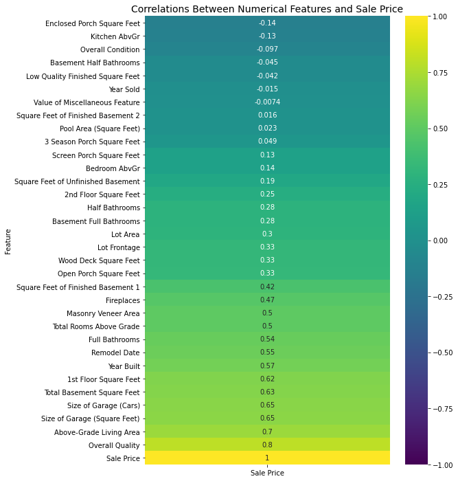

```python
plt.figure(figsize=(8, 12))
sns.heatmap(corr_matrix, annot = True, vmin = -1, vmax = 1, cmap = 'viridis')
plt.title('Correlations Between Numerical Features and Sale Price', fontdict={'fontsize':14})
plt.ylabel('Feature');
```

```python
corr_target = abs(corr_matrix)
salient_num_features = corr_target.loc[corr_target['Sale Price'] > 0.5, :]
salient_num_features
```

|  | Sale Price |
| --- | --- |
| Masonry Veneer Area | 0.503579 |
| Total Rooms Above Grade | 0.504014 |
| Full Bathrooms | 0.537969 |
| Remodel Date | 0.550370 |
| Year Built | 0.571849 |
| 1st Floor Square Feet | 0.618486 |
| Total Basement Square Feet | 0.629303 |
| Size of Garage (Cars) | 0.647781 |
| Size of Garage (Square Feet) | 0.649897 |
| Above-Grade Living Area | 0.697038 |
| Overall Quality | 0.800207 |
| Sale Price | 1.000000 |

#### Target (Sale Price)

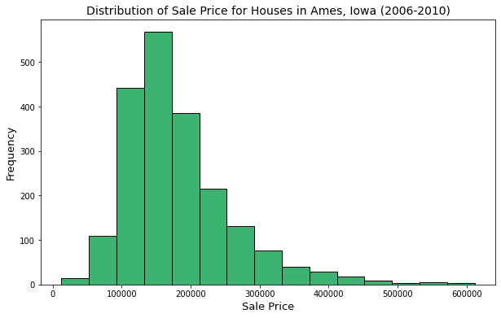

```python
create_hist(housing['SalePrice'],
            num_bins = 15,
            title = 'Distribution of Sale Price for Houses in Ames, Iowa (2006-2010)',
           x_label = 'Sale Price',
           y_label = 'Frequency')
```

The distribution for the target is not normally distributed. It has a right skew. When creating my linear regression model, I might want to consider logging y.

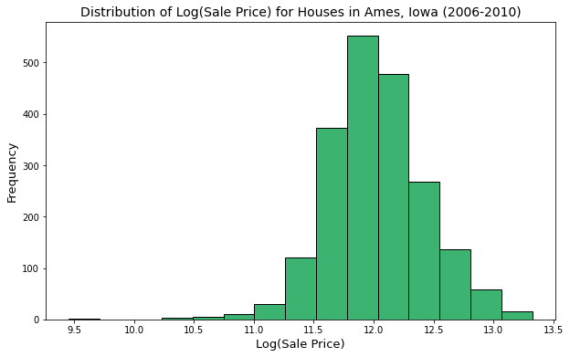

```python
create_hist(np.log(housing['SalePrice']),
            num_bins = 15,
            title = 'Distribution of Log(Sale Price) for Houses in Ames, Iowa (2006-2010)',
           x_label = 'Log(Sale Price)',
           y_label = 'Frequency')
```

Logging the distribution helps normalize the data a little, but now there is a slight left skew.

#### Features

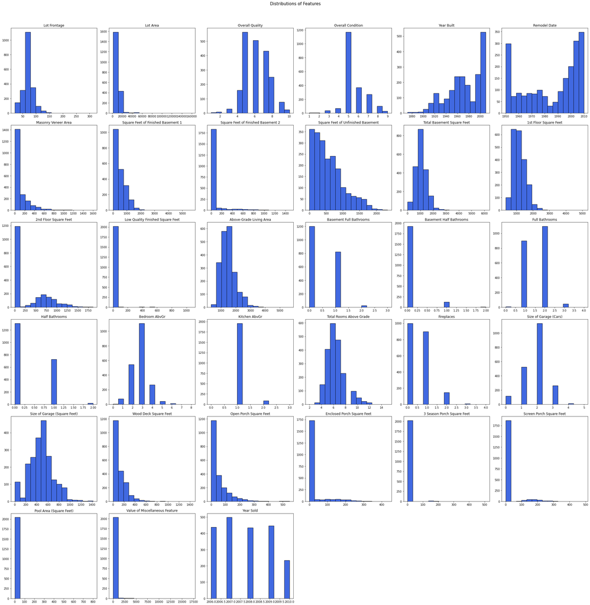

```python
vis_df.drop(columns='Sale Price').hist(figsize=(30, 30), bins = 15, edgecolor = 'black', grid = False, color = 'royalblue')
plt.suptitle('Distributions of Features', x = 0.5, y = 1.02, size = 15)
plt.tight_layout();
```

The above plots show the distributions for each variable. These plots were created as a quick visual to assess the normality of the data. As shown above, the distributions for the majority of numeric features do not appear to be normally distributed.

# EXPERIMENT 3

#### Feature Selection

```python
train_index_marker = len(housing)

train_and_test = pd.concat(objs=[housing, test], axis = 0)
train_and_test.head(3)
```

|  | Id | PID | MS SubClass | MS Zoning | Lot Frontage | Lot Area | Street | Alley | Lot Shape | Land Contour | Utilities | Lot Config | Land Slope | Neighborhood | Condition 1 | Condition 2 | Bldg Type | House Style | Overall Qual | Overall Cond | Year Built | Year Remod/Add | Roof Style | Roof Matl | Exterior 1st | Exterior 2nd | Mas Vnr Type | Mas Vnr Area | Exter Qual | … |
| --- | --- | --- | --- | --- | --- | --- | --- | --- | --- | --- | --- | --- | --- | --- | --- | --- | --- | --- | --- | --- | --- | --- | --- | --- | --- | --- | --- | --- | --- | --- |
| 0 | 109 | 533352170 | 60 | RL | 69.0552 | 13517 | Pave | NA | IR1 | Lvl | AllPub | CulDSac | Gtl | Sawyer | RRAe | Norm | 1Fam | 2Story | 6 | 8 | 1976 | 2005 | Gable | CompShg | HdBoard | Plywood | BrkFace | 289.0 | Gd | … |
| 1 | 544 | 531379050 | 60 | RL | 43.0000 | 11492 | Pave | NA | IR1 | Lvl | AllPub | CulDSac | Gtl | SawyerW | Norm | Norm | 1Fam | 2Story | 7 | 5 | 1996 | 1997 | Gable | CompShg | VinylSd | VinylSd | BrkFace | 132.0 | Gd | … |
| 2 | 153 | 535304180 | 20 | RL | 68.0000 | 7922 | Pave | NA | Reg | Lvl | AllPub | Inside | Gtl | NAmes | Norm | Norm | 1Fam | 1Story | 5 | 7 | 1953 | 2007 | Gable | CompShg | VinylSd | VinylSd | None | 0.0 | TA | … |

### Functions

```python
def create_total_baths(df):
    df['total_baths'] = df['Full Bath'] + df['Bsmt Full Bath'] + 0.5 * (df['Bsmt Half Bath'] + df['Half Bath'])
```

```python
def drop_baths_columns(df):
    '''
    Drops columns used to create "Total Baths" feature
    '''
    df.drop(columns = ['Bsmt Full Bath', 'Bsmt Half Bath', 'Half Bath', 'Full Bath'], inplace = True)
```

```python
def create_liveable_sf(df):
    df['liveable_sf'] = df['BsmtFin SF 1'] + df['BsmtFin SF 2'] + df['Gr Liv Area']
```

```python
def drop_liveable_sf_columns(df):
    '''
    Drops all columns directly related to "Liveable SF" feature
    '''
    df.drop(columns = ['BsmtFin SF 1', 'BsmtFin SF 2', 'Gr Liv Area', '1st Flr SF', '2nd Flr SF'], inplace = True)
```

### Create Features

#### Create a feature for total number of baths per home

```python
create_total_baths(train_and_test)
```

```python
drop_baths_columns(train_and_test)
```

#### Create a feature for total livable sq feet in the house

```python
create_liveable_sf(train_and_test)
```

```python
drop_liveable_sf_columns(train_and_test)
```

#### Explore if a 'Garage' Feature Can Be Built

```python
train_and_test.columns[train_and_test.columns.str.contains('Garage')]
```

```
Index(['Garage Type', 'Garage Yr Blt', 'Garage Finish', 'Garage Cars',
       'Garage Area', 'Garage Qual', 'Garage Cond'],
      dtype='object')
```

```python
housing.corr()['Garage Area']['SalePrice']
```

```
0.649896849661898
```

```python
housing.corr()['Garage Cars']['SalePrice']
```

```
0.6477813459587413
```

```python
housing.corr()['Garage Area']['Garage Cars']
```

```
0.8934415694476694
```

Because the area of the garage and the number of cars that a garage can fit are highly correlated, I will create an interaction feature to account for this relationship.

```python
housing['garage_area_car_int'] = housing['Garage Area'] * housing['Garage Cars']
```

```python
train_and_test['garage_area_car_int'] = train_and_test['Garage Area'] * train_and_test['Garage Cars']
```

```python
group1 = ['StoneBr', 'NridgeHt', 'Veenker', 'NoRidge', 'GrnHill']
group2 = ['SawyerW', 'CollgCr', 'Somerst', 'Gilbert', 'Crawfor', 'NAmes', 'ClearCr', 'Blmngtn', 'Greens']

train_and_test['neighborhoods_1'] = train_and_test['Neighborhood'].map(lambda name: 1 if name in group1 else 0)
train_and_test['neighborhoods_2'] = train_and_test['Neighborhood'].map(lambda name: 1 if name in group2 else 0)
```

```python
train_and_test.drop(columns = 'Neighborhood', inplace = True)
```

#### Create Three Building Class Features

```python
train_and_test['SubClass20'] = train_and_test['MS SubClass'].map(lambda subclass: 1 if subclass == 20 else 0)
train_and_test['SubClass60'] = train_and_test['MS SubClass'].map(lambda subclass: 1 if subclass == 60 else 0)
train_and_test['SubClass120'] = train_and_test['MS SubClass'].map(lambda subclass: 1 if subclass == 120 else 0)
```

```python
train_and_test.drop(columns = 'MS SubClass', inplace = True)
```

```python
train_and_test['close_to_offsite_feature'] = train_and_test['Condition 1'].map(lambda x: 1 if x in ['PosN', 'PosA'] else 0)
```

```python
train_and_test['close_to_busy_street'] = train_and_test['Condition 1'].map(lambda x: 1 if x in ['Artery', 'Feedr'] else 0)
```

```python
train_and_test.drop(columns = 'Condition 1', inplace = True)
```

#### Create a feature to determine if masonry veneer type is stone

During EDA, stone masonry veneer types were discovered to sell for more.

```python
train_and_test['stone_veneer'] = train_and_test['Mas Vnr Type'].map(lambda x: 1 if x == 'Stone' else 0)
```

```python
train_and_test.drop(columns = 'Mas Vnr Type', inplace = True)
```

#### Create a feature to code if the type of sale is for a new home

New homes typically sold for more, so a dummy variable can be create for this feature.

```python
train_and_test['new_sale'] = train_and_test['Sale Type'].map(lambda x: 1 if x == 'New' else 0)
```

#### Create a feature to code if the sale is an estate transaction

During EDA, it was discovered that estate sales sell for less.

```python
train_and_test['estate'] = train_and_test['Sale Type'].map(lambda x: 1 if x == 'COD' else 0)
```

```python
train_and_test.drop(columns = 'Sale Type', inplace = True)
```

#### Create a feature to denote good living quarters in the basement

EDA revealed that homes with good basement living quarters sell for more.

```python
train_and_test['good_basement'] = train_and_test['BsmtFin Type 1'].map(lambda x: 1 if x == 'GLQ' else 0)
```

```python
train_and_test.drop(columns = 'BsmtFin Type 1', inplace = True)
```

EDA revealed that homes with excellent kitchens sell for more.

```python
train_and_test['excellent_kitchen'] = train_and_test['Kitchen Qual'].map(lambda x: 1 if x == 'Ex' else 0)
```

```python
train_and_test.drop(columns = 'Kitchen Qual', inplace = True)
```

#### Create a column to denote zoning clusters

The 'FV', 'RL', and 'RH' zoning classes appeared to be similar based on Sale Price so were clustered together.

```python
train_and_test['zoning_cluster_1'] = train_and_test['MS Zoning'].map(lambda x: 1 if x in ['FV', 'RL', 'RH'] else 0)
```

```python
train_and_test.drop(columns = 'MS Zoning', inplace = True)
```

#### Create dummy variables for categorical features of interest identified in EDA

For this project, I created several models, including: Linear Regression, Ridge Regression, and Lasso Regression. For the Ridge and Lasso Regression models, I dummied all categorical variables that had not been somehow coded into the model. For Linear Regression, I hand-selected features based on what I found in the EDA and Lasso Regression. Therefore, because different dummy variables are required for the two models, I will work off of two sets of data.

**Models 1-3** - Model with All Remaining Features Dummied (Used for Ridge and Lasso Regression)

```python
# Drop features that have already been coded
dropped_cats = ['Id', 'PID', 'Kitchen Qual', 'BsmtFin Type 1', 'Sale Type', 'Mas Vnr Type', 'Condition 1', 'MS SubClass', 'Neighborhood', 'MS Zoning']
```

```python
dummify_list_1 = [category for category in categorical_vars if category not in dropped_cats]
```

```python
train_and_test_1 = pd.get_dummies(data = train_and_test, columns = dummify_list_1, drop_first = True)
```

**Model 4** - Linear Regression with Handpicked Features

```python
# Dummify hand-selected features
dummify_list_4 = ['Street', 'Land Contour', 'Bldg Type', 'Garage Type', 'Exter Qual', 'Paved Drive']
```

```python
train_and_test_4 = pd.get_dummies(data = train_and_test, columns = dummify_list_4, drop_first = True)
```

### Divide Data Back into Preprocessed Train and Test Sets

#### Models 1-3: Ridge and Lasso Regression

```python
# Split into Train
train_preprocessed_1 = train_and_test_1[:train_index_marker]
```

```python
# Split into Test
test_preprocessed_1 = train_and_test_1[train_index_marker:]
```

#### Model 4: Linear Regression with Handpicked Features

```python
# Split into Train
train_preprocessed_4 = train_and_test_4[:train_index_marker]
```

```python
# Split into Test
test_preprocessed_4 = train_and_test_4[train_index_marker:]
```

## Model

```python
X_1 = train_preprocessed_1.drop(columns = ['SalePrice', 'zoning_cluster_1']) # Drop Zoning Cluster - Was Created After Lasso
y_1 = train_preprocessed_1['SalePrice']
```

```python
X_train_1, X_test_1, y_train_1, y_test_1 = train_test_split(X_1, y_1, test_size = 0.2, random_state = 1234567)
```

```python
X_holdout_1 = test_preprocessed_1.drop(columns = ['SalePrice', 'zoning_cluster_1'])
```

```python
cols_to_drop = ['Id', 'PID', 'Utilities', 'Lot Config', 'Land Slope', 'Condition 2', 'House Style', 'Roof Style', 'Exterior 1st', 'Exterior 2nd', 'Exter Cond', 'Bsmt Qual', 'Bsmt Cond', 'Bsmt Exposure', 'BsmtFin Type 2', 'Total Bsmt SF', 'Heating', 'Heating QC', 'Central Air', 'Electrical', 'Bedroom AbvGr', 'Kitchen AbvGr', 'Functional', 'Fireplaces', 'Fireplace Qu', 'Garage Yr Blt', 'Garage Finish', 'Garage Qual', 'Garage Cond', 'Wood Deck SF', 'Open Porch SF', 'Enclosed Porch', '3Ssn Porch', 'Screen Porch', 'Pool Area', 'Pool QC', 'Fence', 'Misc Feature', 'Misc Val', 'SalePrice', 'Alley', 'Lot Shape','Foundation', 'Mo Sold', 'Low Qual Fin SF', 'Roof Matl']

X_4 = train_preprocessed_4.drop(columns = cols_to_drop)
y_4 = np.log(train_preprocessed_4['SalePrice']) # log y to normalize distribution!

X_train_4, X_test_4, y_train_4, y_test_4 = train_test_split(X_4, y_4, test_size = 0.2, random_state = 42)

X_holdout_4 = test_preprocessed_4.drop(columns = cols_to_drop)
```

## Modeling

### Functions

```python
def display_R2_scores(model, X_train, y_train, X_test, y_test):
    print(f'The mean cross validation score for this model is {round(cross_val_score(model, X_train, y_train).mean(),4)}.')
    print(f'The training score for this model is {round(model.score(X_train, y_train), 4)}.')
    print(f'The testing score for this model is {round(model.score(X_test, y_test),4)}.')
```

### Baseline/ Null Model

#### Instantiate and Fit Model

```python
dr = DummyRegressor()
```

```python
dr.fit(X_train_1, y_train_1);
```

#### Evaluate R2 Scores

```python
display_R2_scores(dr, X_train_1, y_train_1, X_test_1, y_test_1)
```

```
The mean cross validation score for this model is -0.0044.
The training score for this model is 0.0.
The testing score for this model is -0.0007.
```

#### Thoughts on the Model

In this scenario, just predicting the mean Sale Price will explain ~0% of the variation in our target. Any model that is able to explain any variation in the target will be a vast improvement.

### Model 1: Linear Regression (As Precursor to Ridge and Lasso)

#### Instantiate and Fit Model

```python
lr_prelim = LinearRegression()
```

```python
lr_prelim.fit(X_train_1, y_train_1);
```

#### Evaluate R2 Score

```python
display_R2_scores(lr_prelim, X_train_1, y_train_1, X_test_1, y_test_1)
```

```
The mean cross validation score for this model is 0.7221.
The training score for this model is 0.9455.
The testing score for this model is 0.7625.
```

### Model 2: Ridge Regression

#### Scale the Data (Can also be used with LASSO)

```python
ss = StandardScaler()
Z_train = ss.fit_transform(X_train_1)
Z_test = ss.transform(X_test_1)
scaled_holdout = ss.transform(X_holdout_1)
```

#### Instantiate and Fit the Model

```python
ridge = Ridge(alpha = 1025) # To improve my Ridge, I manually adjusted the alpha score; the Ridge CV returned smaller alphas (even if the upper limit was increased)
ridge = ridge.fit(Z_train, y_train_1)

# Code taught by Tim Book
```

#### Evaluate R2 Scores

```python
display_R2_scores(ridge, Z_train, y_train_1, Z_test, y_test_1)
```

```
The mean cross validation score for this model is 0.844.
The training score for this model is 0.8976.
The testing score for this model is 0.8189.
```

### Model 3: Lasso Regression

#### Instantiate and Fit the Model

```python
lasso = Lasso(alpha = 5000, max_iter = 4000)
lasso.fit(Z_train, y_train_1);

# Code taught by Tim Book
```

#### Evaluate R2 Scores

```python
display_R2_scores(lasso, Z_train, y_train_1, Z_test, y_test_1)
print(f'The number of features in this model is : {np.sum(lasso.coef_ != 0)}.')
```

```
The mean cross validation score for this model is 0.8074.
The training score for this model is 0.8458.
The testing score for this model is 0.8079.
The number of features in this model is : 20.
```

#### Look at Coefficients that Remain in Model

```python
# Code from Jose Portilla's Data Science Class on Udemy
lasso_coef = pd.DataFrame(lasso.coef_, X_train_1.columns, columns = ['Coefficient'])
pd.set_option('display.max_rows', None)
```

```python
# COMMENTED OUT TO PREVENT CLOGGING NOTEBOOK!
# Only select coefficients that Lasso kept
lasso_coef[lasso_coef['Coefficient'] != 0].sort_values('Coefficient', ascending = False)
```

|  | Coefficient |
| --- | --- |
| Overall Qual | 23598.855344 |
| liveable_sf | 19313.652184 |
| garage_area_car_int | 10662.485581 |
| excellent_kitchen | 8712.010478 |
| Total Bsmt SF | 3806.161331 |
| Year Remod/Add | 3748.958049 |
| TotRms AbvGrd | 2653.886403 |
| Mas Vnr Area | 2639.536991 |
| neighborhoods_1 | 2376.214737 |
| new_sale | 2273.308235 |
| Year Built | 2070.334712 |
| Bsmt Exposure_Gd | 1951.768519 |
| Lot Area | 1754.346909 |
| Fireplaces | 1471.982828 |
| Garage Yr Blt_2009.0 | 434.200954 |
| Foundation_PConc | 392.144252 |
| Heating QC_TA | -858.301278 |
| Fireplace Qu_NA | -1459.242748 |
| Pool QC_Gd | -1990.361535 |
| Exter Qual_TA | -3816.896803 |

### Model 4: Linear Regression with Features Identified in EDA and Lasso

#### Instantiate and Fit Model

```python
lr = LinearRegression()
```

```python
lr.fit(X_train_4, y_train_4);
```

#### Evaluate R2 Scores

```python
display_R2_scores(lr, X_train_4, y_train_4, X_test_4, y_test_4)
print(f'The number of features in this model is : {np.sum(lr.coef_ != 0)}.')
```

```
The mean cross validation score for this model is 0.8448.
The training score for this model is 0.8745.
The testing score for this model is 0.8783.
The number of features in this model is : 47.
```

#### Thoughts on Model

Of the models that I created, this one performs the best in terms of R2 score. There is low bias and low variance. With only 47 features, this model explains approximately 87% of the variation in the target (Sale Price) for both the training and testing sets. Because the data has not been scaled, this data also provides the best interpretability.

#### [For Kaggle] Make Predictions to Holdout Data and Save to CSV

```python
lr_preds = np.exp(lr.predict(X_holdout_4))
```

```python
preds_cols = pd.Series(lr_preds, name = 'SalePrice')
id_col = test_preprocessed_1['Id']
output = pd.concat([id_col, preds_cols], axis = 1)
output.sort_values('Id', inplace = True)
output.sort_values('Id', inplace = True)
output.set_index('Id', inplace = True)
output.to_csv('../output/final_submission')
```

# EXPERIMENT 2

#### Model Selection

```python
%%html
<style>
table{float:left}
</style>
```

[output not shown]

## Model Evaluation

I will further evaluate the Linear Regression model by calculating the Root Mean Squared Error and by examining the residuals. In order to increase interpretability, the logged y-values will be exponentiated for model evaluation.

### Root Mean Squared Error (RMSE)

```python
y_test = np.exp(y_test_4) # Convert back to actual (non-log) values
y_pred = np.exp(lr.predict(X_test_4)) # Convert back to actual (non-log) values
resids = y_test - y_pred
```

```python
rmse = np.sqrt(mean_squared_error(y_test, y_pred))
print(f'The RMSE is {round(rmse,2)}.')
```

```
The RMSE is 23625.19.
```

According to the value of the RMSE, the predictions for Sale Price made by the Linear Regression model are likely off by about $23,625.19. This is less than 1/3 of the standard deviation of the Sale Price in the training data. Although I would like to improve this number to increase the predictability of the model, this is a good starting point to improve from.

### How do the predictions of Sale Price compare to the actual values?

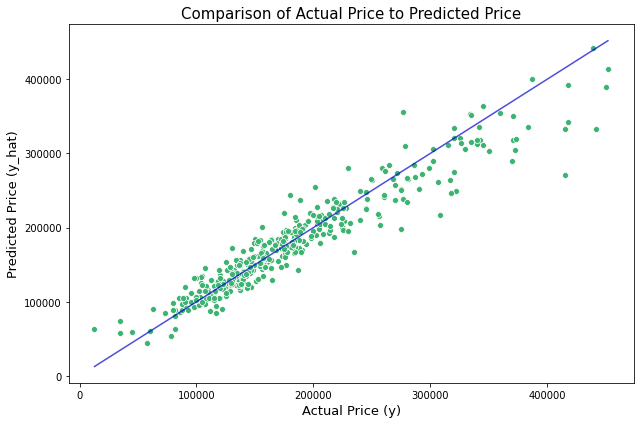

```python
plt.figure(figsize = (9, 6))
sns.scatterplot(x = y_test, y = y_pred, color = 'mediumseagreen')
plt.title('Comparison of Actual Price to Predicted Price', fontdict = {'fontsize':15})
maxDist = max(max(y_pred), max(y_test)) # Code from Mahdi's lecture
minDist = min(min(y_pred), min(y_test)) # Code from Mahdi's lecture
sns.lineplot((minDist, maxDist), (minDist, maxDist), color = 'mediumblue', alpha = 0.7) # Similar to Mahdi's code, but done with Seaborn
plt.xlabel('Actual Price (y)', fontdict= {'fontsize':13})
plt.ylabel('Predicted Price (y_hat)', fontdict= {'fontsize':13})
plt.tight_layout();
```